# R LadiesLima Analizar datos electorales con R

Marylía Cruz

29/08/2020

**ÍNDICE**

**DESARROLLO**

**Descargar las bases de datos y los paquetes a utilizar**

Descargar las bases de candidatos de las elecciones municipales provinciales del 2002, 2006, 2010, 2014 y 2018 del siguiente link: https://infogob.jne.gob.pe/BaseDatos

```r
#install.packages("dplyr")
library(dplyr) # para el gráfico estático
```

```r
#install.packages("ggplot2")
library(ggplot2) # para el gráfico estático

#install.packages("gganimate")
library(gganimate) # para el gráfico animado

#install.packages("gifski")
library(gifski)  # para el gráfico animado

#install.packages("av")
library(av) # para el gráfico animado
```

**Cambiar de directorio de trabajo**

Una vez descargadas las bases de datos, crea una carpeta en tu ordenador donde se ubiquen todas las bases de datos a utilizar. En mi caso, cree la carpeta TallerRLadiesLima. La ruta es mi carpeta es “~/Documentos/GitHub/TallerRLadiesLima” Si no sabes la ruta de tu carpeta, también puede ir al menú : SESION-SET WORKING DIRECTORY-CHOOSE DIRECTORY

```r
setwd("~/Documentos/GitHub/TallerRLadiesLima")
```

**Abrir la base de datos**

```r
library(readxl) #install.packages("readxl")
Candidatos2002 <- read_excel("ERM2002_Candidatos_Provincial.xlsx")
Candidatos2006 <- read_excel("ERM2006_Candidatos_Provincial.xlsx")
Candidatos2010 <- read_excel("ERM2010_Candidatos_Provincial.xlsx")
Candidatos2014 <- read_excel("ERM2014_Candidatos_Provincial.xlsx")
Candidatos2018 <- read_excel("ERM2018_Candidatos_Provincial.xlsx")

Ubigeo <- read_excel("Ubigeo.xlsx")
```

**Manejo de las bases de datos**

El comando “names” muestra el nombre de las variables.

```r
names(Candidatos2002)
```

```
##  [1] "Región"                     "Provincia"
##  [3] "Organización Política"      "Tipo Organización Política"
##  [5] "Cargo"                      "N°"
##  [7] "Primer apellido"            "Segundo apellido"
##  [9] "Prenombres"                 "Sexo"
## [11] "Joven"                      "Nativo"
```

```r
names(Candidatos2006)
```

```
##  [1] "Región"                     "Provincia"
##  [3] "Organización Política"      "Tipo Organización Política"
##  [5] "Cargo"                      "N°"
##  [7] "Primer apellido"            "Segundo apellido"
##  [9] "Prenombres"                 "Sexo"
## [11] "Joven"                      "Nativo"
```

```r
names(Candidatos2010)
```

```
##  [1] "Región"                     "Provincia"
##  [3] "Organización Política"      "Tipo Organización Política"
##  [5] "Cargo"                      "N°"
##  [7] "Primer apellido"            "Segundo apellido"
##  [9] "Prenombres"                 "Sexo"
## [11] "Joven"                      "Nativo"
```

```r
names(Candidatos2014)
```

```
##  [1] "Región"                     "Provincia"
##  [3] "Organización Política"      "Tipo Organización Política"
##  [5] "Cargo"                      "N°"
##  [7] "Primer apellido"            "Segundo apellido"
##  [9] "Prenombres"                 "Sexo"
## [11] "Joven"                      "Nativo"
```

```r
names(Candidatos2018)
```

```
##  [1] "Región"                     "Provincia"
##  [3] "Organización Política"      "Tipo Organización Política"
##  [5] "Cargo"                      "N°"
##  [7] "Primer apellido"            "Segundo apellido"
##  [9] "Prenombres"                 "Sexo"
## [11] "Joven"                      "Nativo"
```

Creo una nueva variable “anio” que indica el año de elección en cada base de datos

```r
Candidatos2002$anio=2002
Candidatos2006$anio=2006
Candidatos2010$anio=2010
Candidatos2014$anio=2014
Candidatos2018$anio=2018
```

Junto todas las bases de datos en una sola base de datos.

```r
lista=list(Candidatos2002,Candidatos2006,Candidatos2010,Candidatos2014,Candidatos2018)
#list = crea una lista de elementos
# rbind= junta filas de distintas bases de datos
# do.call =  repite una acción del código
# as.data.frame =  como base de datos
Candidatos=as.data.frame(do.call(rbind,lista))
```

Utilizar el comando “merge” para juntar las bases de datos de los candidatos de las elecciones provinciales y la de ubigeo.

```r
Candidatos=merge(Candidatos,Ubigeo,by.x="Provincia",by.y="Provincia")
names(Candidatos)
```

```
##  [1] "Provincia"                  "Región"
##  [3] "Organización Política"      "Tipo Organización Política"
##  [5] "Cargo"                      "N°"
##  [7] "Primer apellido"            "Segundo apellido"
##  [9] "Prenombres"                 "Sexo"
## [11] "Joven"                      "Nativo"
## [13] "anio"                       "UBIGEO"
```

Definir las variables según el tipo

```r
str(Candidatos)
```

```
## 'data.frame':    90391 obs. of  14 variables:
##  $ Provincia                 : chr  "ABANCAY" "ABANCAY" "ABANCAY" "ABANCAY" ...
##  $ Región                    : chr  "APURIMAC" "APURIMAC" "APURIMAC" "APURIMAC" ...
##  $ Organización Política     : chr  "UNION POR EL PERU" "PARTIDO DEMOCRATICO SOMOS PERU" "PARTIDO DEMOCRATICO SOMOS PERU" "ACCION POPULAR" ...
##  $ Tipo Organización Política: chr  "PARTIDO POLÍTICO" "PARTIDO POLÍTICO" "PARTIDO POLÍTICO" "PARTIDO POLÍTICO" ...
##  $ Cargo                     : chr  "ALCALDE PROVINCIAL" "REGIDOR PROVINCIAL" "REGIDOR PROVINCIAL" "REGIDOR PROVINCIAL" ...
##  $ N°                        : num  0 9 10 5 8 0 11 2 3 1 ...
##  $ Primer apellido           : chr  "ELGUERA" "PINTO" "ACUÑA" "CASTAÑEDA" ...
##  $ Segundo apellido          : chr  "HILARES" "MEDINA" "NUÑEZ" "BEINGOLEA DE GAJETZKY" ...
##  $ Prenombres                : chr  "MARYLUZ" "MARIA DEL CARMEN" "EVELYN ROSALY DUVERLY" "ADELA" ...
##  $ Sexo                      : chr  "Femenino" "Femenino" "Femenino" "Femenino" ...
##  $ Joven                     : chr  NA "Joven" "Joven" NA ...
##  $ Nativo                    : chr  NA NA NA NA ...
##  $ anio                      : num  2018 2018 2018 2018 2018 ...
##  $ UBIGEO                    : chr  "0301" "0301" "0301" "0301" ...
```

```r
Candidatos$Sexo=as.factor(Candidatos$Sexo)
Candidatos$Cargo=as.factor(Candidatos$Cargo)
```

**PREGUNTA 1: ¿Se ha incrementado la participación política de las mujeres en las elecciones provinciales?**

##### CREANDO TABLAS

El comando “table” siver para crear tablas de frecuencias.

```r
tablaresumen=table(Candidatos$Sexo,Candidatos$anio)
```

```r
# El comando "prop.table" siver para crear tablas de proporciones
# El número 2  indica que se desea porcentajes por columnas.
# Se coloca *100 para multiplicar por 100 las proporciones de 0 a 1.
prop.table(table(Candidatos$Sexo,Candidatos$anio),2)*100
```

```
##
##                 2002     2006     2010     2014     2018
##   Femenino  35.52988 37.63259 38.51767 39.26941 39.99901
##   Masculino 64.47012 62.36741 61.48233 60.73059 60.00099
```

```r
prop.table(table(Candidatos$Sexo,Candidatos$anio),2)
```

```
##
##                  2002      2006      2010      2014      2018
##   Femenino  0.3552988 0.3763259 0.3851767 0.3926941 0.3999901
##   Masculino 0.6447012 0.6236741 0.6148233 0.6073059 0.6000099
```

##### GRAFICO SENCILLO SIN GGPLOT2

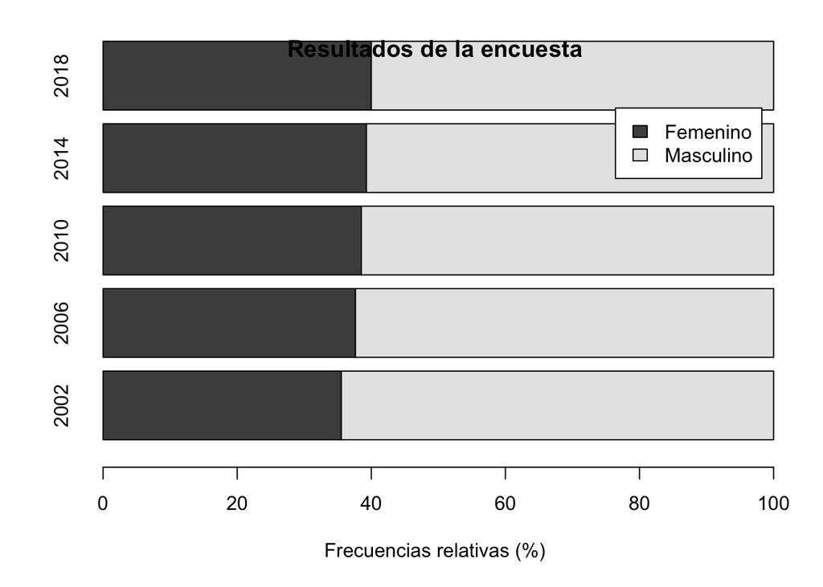

```r
###El comando "barplot" se utiliza para realizar gráfico de barras
barplot(prop.table(tablaresumen,2)*100,
        main = "Resultados de la encuesta",
        xlab = "Frecuencias relativas (%)",
        legend = T,
        width = 0.5, ylim = c(0, 2.5),
        horiz = T)
```

##### INSUMOS PARA GRÁFICO

```r
#tablaresumen=table(Candidatos$Sexo,Candidatos$anio)
as.data.frame(tablaresumen)
```

| Var1 | Var2 | Freq |
| --- | --- | --- |
| Femenino | 2002 | 6303 |
| Masculino | 2002 | 11437 |
| Femenino | 2006 | 6244 |
| Masculino | 2006 | 10348 |
| Femenino | 2010 | 6704 |
| Masculino | 2010 | 10701 |
| Femenino | 2014 | 7224 |
| Masculino | 2014 | 11172 |
| Femenino | 2018 | 8103 |
| Masculino | 2018 | 12155 |

```r
#Uso el comando "aggregate" para resumir tablas y calcular la suma total de candidatos por años
tabla_general=aggregate(Freq ~ Var2, data = tablaresumen, sum)
```

```r
#Usar el comando "merge" para juntar la tabla anterior con la tabla resumen
Candidatos_tabla1=merge(tablaresumen,tabla_general,by=c("Var2"))
```

Calcular la proporción de la cantidad de mujeres y la cantidad total de candidatos

```r
Candidatos_tabla1$Proporcion=Candidatos_tabla1$Freq.x/Candidatos_tabla1$Freq.y
```

Se crea una lista de nombres nuevos para renombrar Candidatos_tabla1.

```r
names(Candidatos_tabla1) <- c("anio", "Sexo","Frecuencia","Total_Candidatos","Proporcion")
```

Redefino el formato de la variable anio . Utilizo el comando “as.numeric” para definir como variable numérica a anio.

```r
Candidatos_tabla1$anio=as.numeric(Candidatos_tabla1$anio)
```

##### GRÁFICO ESTÁTICO

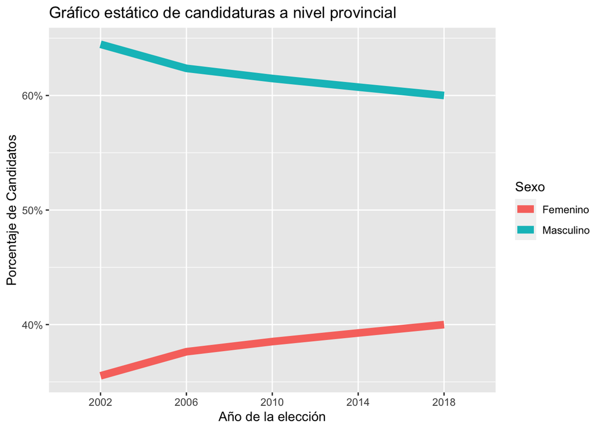

```r
grafico1estatico=ggplot(Candidatos_tabla1,aes(x=anio, y=Proporcion, group=Sexo,
                                              color=Sexo))+
  geom_line(size=3) +
  scale_y_continuous(labels = scales::percent_format(accuracy = 1))+
  labs(x="Año de la elección",y="Porcentaje de Candidatos",title="Gráfico estático de candidaturas a nivel provincial")

grafico1estatico+ scale_x_discrete(limits=c("2002","2006","2010","2014","2018"))
```

##### GRÁFICO ANIMADO

```r
grafico1dinamico=ggplot(Candidatos_tabla1,aes(x=anio, y=Proporcion, group=Sexo,
                                              color=Sexo))+
  geom_line(size=3) +
  scale_y_continuous(labels = scales::percent_format(accuracy = 1))+
  labs(x="año de la elección",y="Porcentaje de Candidatos",title="Gráfico animado de candidaturas a nivel provincial" ) +
  transition_reveal(anio)
```

[figure not shown]

```r
grafico1dinamico + scale_x_discrete(limits=c("2002","2006","2010","2014","2018"))
```

Guardar el gif

```r
anim_save("grafico1dinamico.gif")
```

**PREGUNTA 2: ¿A qué cargos postulan más las mujeres en elecciones provinciales?**

##### INSUMOS PARA GRÁFICO

Uso el comando “table” para crear una tabla de frecuencia de sexo, anio y cargo.

```r
tabla=as.data.frame(table(Candidatos$Sexo,Candidatos$anio,Candidatos$Cargo))
tabla
```

| Var1 | Var2 | Var3 | Freq |
| --- | --- | --- | --- |
| Femenino | 2002 | ALCALDE PROVINCIAL | 117 |
| Masculino | 2002 | ALCALDE PROVINCIAL | 1634 |
| Femenino | 2006 | ALCALDE PROVINCIAL | 126 |
| Masculino | 2006 | ALCALDE PROVINCIAL | 1505 |
| Femenino | 2010 | ALCALDE PROVINCIAL | 108 |
| Masculino | 2010 | ALCALDE PROVINCIAL | 1612 |
| Femenino | 2014 | ALCALDE PROVINCIAL | 143 |
| Masculino | 2014 | ALCALDE PROVINCIAL | 1630 |
| Femenino | 2018 | ALCALDE PROVINCIAL | 171 |
| Masculino | 2018 | ALCALDE PROVINCIAL | 1714 |

[output cut: 10 more lines]

El comando “aggregate” sirve crear una tabla para calcular cantidad total de candidatos y de cantidad total de candidatos a regidores a nivel provincial

```r
tabla_frecuencia=aggregate(Freq ~ Var2+Var3, data = tabla, sum)
tabla_frecuencia
```

| Var2 | Var3 | Freq |
| --- | --- | --- |
| 2002 | ALCALDE PROVINCIAL | 1751 |
| 2006 | ALCALDE PROVINCIAL | 1631 |
| 2010 | ALCALDE PROVINCIAL | 1720 |
| 2014 | ALCALDE PROVINCIAL | 1773 |
| 2018 | ALCALDE PROVINCIAL | 1885 |
| 2002 | REGIDOR PROVINCIAL | 15989 |
| 2006 | REGIDOR PROVINCIAL | 14961 |
| 2010 | REGIDOR PROVINCIAL | 15685 |
| 2014 | REGIDOR PROVINCIAL | 16623 |
| 2018 | REGIDOR PROVINCIAL | 18373 |

Uso el comando “merge” para unir las dos tablas anteriores

```r
Candidatos_tabla2=merge(tabla,tabla_frecuencia,by=c("Var2","Var3"))
Candidatos_tabla2
```

| Var2 | Var3 | Var1 | Freq.x | Freq.y |
| --- | --- | --- | --- | --- |
| 2002 | ALCALDE PROVINCIAL | Femenino | 117 | 1751 |
| 2002 | ALCALDE PROVINCIAL | Masculino | 1634 | 1751 |
| 2002 | REGIDOR PROVINCIAL | Femenino | 6186 | 15989 |
| 2002 | REGIDOR PROVINCIAL | Masculino | 9803 | 15989 |
| 2006 | ALCALDE PROVINCIAL | Femenino | 126 | 1631 |
| 2006 | ALCALDE PROVINCIAL | Masculino | 1505 | 1631 |
| 2006 | REGIDOR PROVINCIAL | Femenino | 6118 | 14961 |
| 2006 | REGIDOR PROVINCIAL | Masculino | 8843 | 14961 |
| 2010 | ALCALDE PROVINCIAL | Femenino | 108 | 1720 |
| 2010 | ALCALDE PROVINCIAL | Masculino | 1612 | 1720 |

[output cut: 10 more lines]

Calculo la proporción de candidatos por sexo

```r
Candidatos_tabla2$Proporcion=Candidatos_tabla2$Freq.x/Candidatos_tabla2$Freq.y
```

Se crea una lista de nombres nuevos para renombrar Candidatos_tabla2

```r
names(Candidatos_tabla2) <- c("anio", "Cargo","Sexo","Frecuencia","Total_Candidatos","Proporcion")
```

Redefino el formato de la variable anio . Utilizo el comando “as.numeric” para definir como variable numérica a anio.

```r
Candidatos_tabla2$anio=as.numeric(Candidatos_tabla2$anio)
```

##### GRÁFICO ESTÁTICO

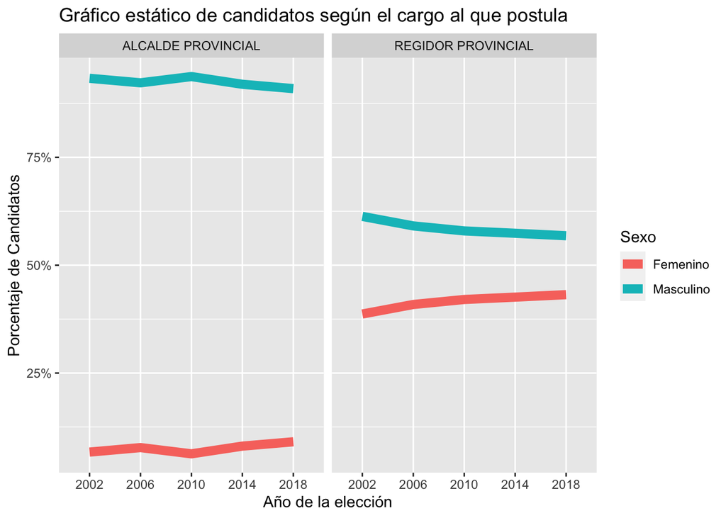

```r
grafico2estatico=ggplot(Candidatos_tabla2,aes(x=anio, y=Proporcion, group=Sexo,
                                              color=Sexo))+
  geom_line(size=3) +
  scale_y_continuous(labels = scales::percent_format(accuracy = 1))+
  labs(x="Año de la elección",y="Porcentaje de Candidatos",title="Gráfico estático de candidatos según el cargo al que postula") +
  facet_wrap(~Cargo,ncol=2,strip.position = "top")
grafico2estatico+ scale_x_discrete(limits=c("2002","2006","2010","2014","2018"))
```

##### GRÁFICO ANIMADO

[figure not shown]

```r
grafico2dinamico=ggplot(Candidatos_tabla2,aes(x=anio, y=Proporcion, group=Sexo,
                                              color=Sexo))+
  geom_line(size=3) +
  scale_y_continuous(labels = scales::percent_format(accuracy = 1))+
  labs(x="Año de la elección",y="Porcentaje de Candidatos",title="Gráfico animado de candidatos según el cargo al que postula") +
  facet_wrap(~Cargo,ncol=2,strip.position = "top")+
  transition_reveal(anio)
grafico2dinamico+ scale_x_discrete(limits=c("2002","2006","2010","2014","2018"))
```

Guardar el gif

```r
anim_save("grafico2dinamico.gif")
```

**PREGUNTA 3: ¿En qué provincias postulan más las mujeres?**

```r
TabladeConteo=as.data.frame(table(Candidatos$Sexo,Candidatos$anio,Candidatos$UBIGEO))
```

Crear la tabla de mujeres , y otra de varones

```r
CandidatAs <- subset(TabladeConteo, TabladeConteo$Var1 == "Femenino")
CandidatOs <- subset(TabladeConteo, TabladeConteo$Var1 == "Masculino")
```

Cambios de nombres a las bases de datos creadas.

```r
names(CandidatAs) <- c("Femenino", "anio","UBIGEO","FrecuenciaMujeres")
names(CandidatOs) <- c("Masculino", "anio","UBIGEO","FrecuenciaVarones")
```

Usamos el comando “merge” para unir las dos bases anteriores entre UBIGEO y anio.

```r
DataConteo=merge(CandidatOs,CandidatAs,by.x=c("UBIGEO","anio"),by.y=c("UBIGEO","anio"))
```

Seleccionamos las vables que utilizaremos.

```r
DataConteo=select(DataConteo, UBIGEO, anio,FrecuenciaMujeres,FrecuenciaVarones)
```

Creamos una variable “el número de candidatos”.

```r
DataConteo$FrecuenciaTotal=DataConteo$FrecuenciaMujeres+DataConteo$FrecuenciaVarones
```

Creamos las variables sobre porcentajes de mujeres candidatas y hombres candidatos

```r
DataConteo$Porcentaje_Mujeres=(DataConteo$FrecuenciaMujeres/DataConteo$FrecuenciaTotal)*100
DataConteo$Porcentaje_Varones=(DataConteo$FrecuenciaVarones/DataConteo$FrecuenciaTotal)*100
```

Resumen de las variables

```r
summary(DataConteo$Porcentaje_Mujeres)
```

```
##    Min. 1st Qu.  Median    Mean 3rd Qu.    Max.    NA's
##   26.09   34.85   37.50   37.66   40.18   49.56       5
```

```r
summary(DataConteo$Porcentaje_Varones)
```

```
##    Min. 1st Qu.  Median    Mean 3rd Qu.    Max.    NA's
##   50.44   59.82   62.50   62.34   65.15   73.91       5
```

A los NA, les colocamos 0 . Pueden obtener 0 porque hubieron provincias nuevas creadas desde el 2002

```r
DataConteo$Porcentaje_Mujeres[is.na(DataConteo$Porcentaje_Mujeres)] = 0
DataConteo$Porcentaje_Varones[is.na(DataConteo$Porcentaje_Varones)] = 0
```

Juntamos la data anterior con Ubigeo para saber los nombres.

```r
DataConteo=merge(DataConteo,Ubigeo,by="UBIGEO",all.x = TRUE)
```

Reordenamos la base de datos de mayor a menor por el Porcentaje de Mujeres. Usamos el comando order para lo mencionado.

```r
DataConteo <- DataConteo[with(DataConteo, order(-DataConteo$Porcentaje_Mujeres)), ]
```

¿Cuales son las provincias donde más participan las mujeres en elecciones?

```r
head(DataConteo, 5)
```

|  | UBIGEO | anio | FrecuenciaMujeres | FrecuenciaVarones | FrecuenciaTotal | Porcentaje_Mujeres | Porcentaje_Varones | Provincia |
| --- | --- | --- | --- | --- | --- | --- | --- | --- |
| 660 | 1505 | 2018 | 113 | 115 | 228 | 49.56140 | 50.43860 | CAÑETE |
| 569 | 1302 | 2014 | 46 | 47 | 93 | 49.46237 | 50.53763 | ASCOPE |
| 725 | 1608 | 2018 | 32 | 34 | 66 | 48.48485 | 51.51515 | PUTUMAYO |
| 956 | 2403 | 2002 | 11 | 12 | 23 | 47.82609 | 52.17391 | ZARUMILLA |
| 604 | 1309 | 2014 | 43 | 47 | 90 | 47.77778 | 52.22222 | SANCHEZ CARRION |

Guarda la base de datos

```r
library(openxlsx) #install.packages("openxlsx")
write.xlsx(DataConteo,"DataConteo.xlsx")
```

##### GRÁFICOS BOXPLOT

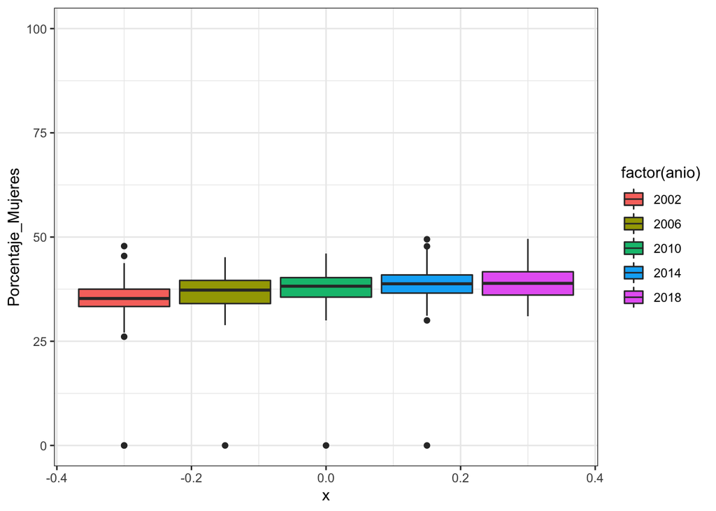

```r
boxplotMujeres <- ggplot(DataConteo, aes(x=0, y=Porcentaje_Mujeres))
boxplotMujeres + geom_boxplot(aes(fill=factor(anio))) + theme_bw()+ylim(0,100)
```

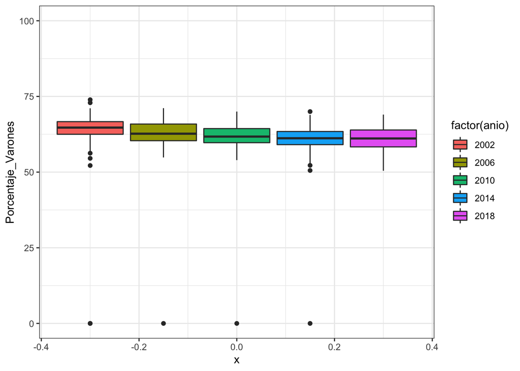

```r
boxplotVarones <- ggplot(DataConteo, aes(x=0, y=Porcentaje_Varones))
boxplotVarones + geom_boxplot(aes(fill=factor(anio))) + theme_bw()+ylim(0,100)
```

Filtremos la base de datos para obtener solo los datos del 2018. Utilizamos el comando “subset” para ello.

```r
DataConteo2018 <- subset(DataConteo, DataConteo$anio == "2018")
DataConteo2018 <- DataConteo2018[with(DataConteo2018, order(-DataConteo2018$Porcentaje_Mujeres)), ] #
head(DataConteo2018, 5)
```

|  | UBIGEO | anio | FrecuenciaMujeres | FrecuenciaVarones | FrecuenciaTotal | Porcentaje_Mujeres | Porcentaje_Varones | Provincia |
| --- | --- | --- | --- | --- | --- | --- | --- | --- |
| 660 | 1505 | 2018 | 113 | 115 | 228 | 49.56140 | 50.43860 | CAÑETE |
| 725 | 1608 | 2018 | 32 | 34 | 66 | 48.48485 | 51.51515 | PUTUMAYO |
| 810 | 2008 | 2018 | 43 | 47 | 90 | 47.77778 | 52.22222 | SECHURA |
| 170 | 0307 | 2018 | 15 | 17 | 32 | 46.87500 | 53.12500 | GRAU |
| 550 | 1207 | 2018 | 78 | 90 | 168 | 46.42857 | 53.57143 | TARMA |

En Cañete, Putumayo, Sechura, Grau y Tarma son las 5 provincias con mayor porcentaje de participación de las mujeres como candidatas a regionas o alcaldesas.

**PREGUNTA 4: ¿En qué provincias postulan más las mujeres a las alcadías provinciales?**

Seleccionar un subconjuntos de datos de las mujeres candidatas al alcalde provincia.

```r
CandidatosAalcaldes <- subset(Candidatos, Candidatos$Cargo == "ALCALDE PROVINCIAL")
```

Crear una tabla por sexo, ubigeo y anio

```r
TablaAlcaldes=as.data.frame(table(CandidatosAalcaldes$Sexo,CandidatosAalcaldes$UBIGEO,CandidatosAalcaldes$anio))
```

Filtramos la tabla por Femenino

```r
TablaAlcaldesAs <- subset(TablaAlcaldes, TablaAlcaldes$Var1 == "Femenino")
```

Filtramos la tabla por Masculino

```r
TablaAlcaldEs <- subset(TablaAlcaldes, TablaAlcaldes$Var1 == "Masculino")
```

Renombramos las variables de nuevas bases de datos creadas

```r
names(TablaAlcaldesAs) <- c("Femenino", "UBIGEO","anio","FrecuenciaMujeres")
names(TablaAlcaldEs) <- c("Masculino", "UBIGEO","anio","FrecuenciaVarones")
```

Juntamos ambas bases de datos

```r
DataConteoAlcades=merge(TablaAlcaldesAs,TablaAlcaldEs,by.x=c("UBIGEO","anio"),by.y=c("UBIGEO","anio"))
```

Seleccionar las variables de la bases de datos

```r
DataConteoAlcades=select(DataConteoAlcades, UBIGEO, anio,FrecuenciaMujeres,FrecuenciaVarones)
```

Crear una nueva variable, suma de la cantidad de total de candidatos a alcaldes

```r
DataConteoAlcades$FrecuenciaTotal=DataConteoAlcades$FrecuenciaMujeres+DataConteoAlcades$FrecuenciaVarones
```

Calcular el porcentaje de mujeres a alcaldes

```r
DataConteoAlcades$Porcentaje_Mujeres=(DataConteoAlcades$FrecuenciaMujeres/DataConteoAlcades$FrecuenciaTotal)
```

Calcular el porcentaje de varones a alcaldes

```r
DataConteoAlcades$Porcentaje_Varones=(DataConteoAlcades$FrecuenciaVarones/DataConteoAlcades$FrecuenciaTotal)
```

Usar el comando “merge” para juntar la base de datos por ubigeo

```r
DataConteoAlcades=merge(DataConteoAlcades,Ubigeo,by="UBIGEO",all.x = TRUE)
```

Ordenar la base de datos de mayor a menor

```r
DataConteoAlcades <- DataConteoAlcades[with(DataConteoAlcades, order(-DataConteoAlcades$Porcentaje_Mujeres)), ] #
```

El comando “head” muestra las cinco primeras filas.

```r
head(DataConteoAlcades, 5)
```

|  | UBIGEO | anio | FrecuenciaMujeres | FrecuenciaVarones | FrecuenciaTotal | Porcentaje_Mujeres | Porcentaje_Varones | Provincia |
| --- | --- | --- | --- | --- | --- | --- | --- | --- |
| 956 | 2403 | 2002 | 2 | 1 | 3 | 0.6666667 | 0.3333333 | ZARUMILLA |
| 170 | 0307 | 2018 | 2 | 2 | 4 | 0.5000000 | 0.5000000 | GRAU |
| 201 | 0407 | 2002 | 2 | 2 | 4 | 0.5000000 | 0.5000000 | ISLAY |
| 759 | 1901 | 2014 | 4 | 5 | 9 | 0.4444444 | 0.5555556 | PASCO |
| 379 | 0809 | 2014 | 3 | 4 | 7 | 0.4285714 | 0.5714286 | LA CONVENCION |

Ordenar la base de datos de menor a mayor

```r
DataConteoAlcades <- DataConteoAlcades[with(DataConteoAlcades, order(DataConteoAlcades$Porcentaje_Mujeres)), ] #
```

El comando “head” muestra las cinco primeras filas.

```r
head(DataConteoAlcades, 5)
```

|  | UBIGEO | anio | FrecuenciaMujeres | FrecuenciaVarones | FrecuenciaTotal | Porcentaje_Mujeres | Porcentaje_Varones | Provincia |
| --- | --- | --- | --- | --- | --- | --- | --- | --- |
| 1 | 0101 | 2002 | 0 | 6 | 6 | 0 | 1 | CHACHAPOYAS |
| 3 | 0101 | 2010 | 0 | 9 | 9 | 0 | 1 | CHACHAPOYAS |
| 8 | 0102 | 2010 | 0 | 9 | 9 | 0 | 1 | BAGUA |
| 9 | 0102 | 2014 | 0 | 8 | 8 | 0 | 1 | BAGUA |
| 10 | 0102 | 2018 | 0 | 8 | 8 | 0 | 1 | BAGUA |

#### PARA GUARDAR LA BASE DATOS CREADA

```r
##install.packages("openxlsx")
library(openxlsx)
# Se usa el comando "write.xlsx"  para guardar datos en la data de excel.
write.xlsx(DataConteoAlcades,"DataConteoAlcades.xlsx")
```

#### GRÁFICOS BOXPLOT

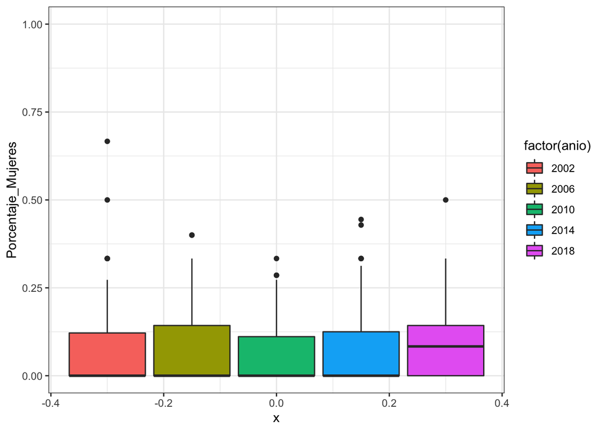

```r
BoxplotDataConteoAlcades <- ggplot(DataConteoAlcades, aes(x=0, y=Porcentaje_Mujeres))
BoxplotDataConteoAlcades + geom_boxplot(aes(fill=factor(anio))) + theme_bw()+ylim(0,1)
```

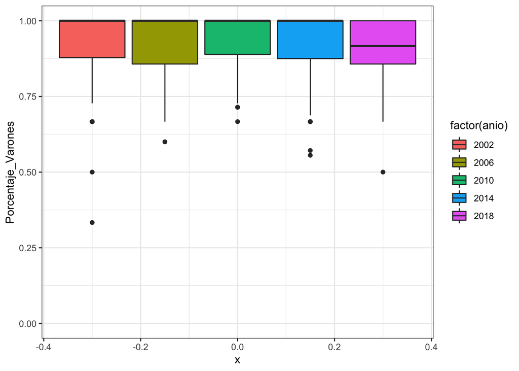

```r
BoxplotDataConteoAlcades <- ggplot(DataConteoAlcades, aes(x=0, y=Porcentaje_Varones))
BoxplotDataConteoAlcades + geom_boxplot(aes(fill=factor(anio))) + theme_bw()+ylim(0,1)
```

Crear una base de datos de provincias con ninguna candidata a alcalcde

```r
NingunaMujerCandidataAlcade=DataConteoAlcades[which(DataConteoAlcades$Porcentaje_Mujeres == 0),]
```

Filtremos la base de datos para obtener solo los datos del 2018. Utilizamos el comando “subset” para ello.

```r
DataConteoAlcades2018 <- subset(DataConteoAlcades, DataConteoAlcades$anio == "2018")
DataConteoAlcades2018 <- DataConteoAlcades2018[with(DataConteoAlcades2018, order(-DataConteoAlcades2018$Porcentaje_Mujeres)), ] #
head(DataConteoAlcades2018, 5)
```

|  | UBIGEO | anio | FrecuenciaMujeres | FrecuenciaVarones | FrecuenciaTotal | Porcentaje_Mujeres | Porcentaje_Varones | Provincia |
| --- | --- | --- | --- | --- | --- | --- | --- | --- |
| 170 | 0307 | 2018 | 2 | 2 | 4 | 0.5000000 | 0.5000000 | GRAU |
| 205 | 0407 | 2018 | 3 | 6 | 9 | 0.3333333 | 0.6666667 | ISLAY |
| 250 | 0508 | 2018 | 3 | 6 | 9 | 0.3333333 | 0.6666667 | PAUCAR DEL SARA SARA |
| 705 | 1604 | 2018 | 3 | 6 | 9 | 0.3333333 | 0.6666667 | MARISCAL RAMON CASTILLA |
| 70 | 0207 | 2018 | 2 | 5 | 7 | 0.2857143 | 0.7142857 | CARLOS FERMIN FITZCARRALD |

Ordenamos la base de datos según el 2018.

```r
DataConteoAlcades2018 <- DataConteoAlcades2018[with(DataConteoAlcades2018, order(DataConteoAlcades2018$Porcentaje_Mujeres)), ] #
head(DataConteoAlcades2018, 5)
```

|  | UBIGEO | anio | FrecuenciaMujeres | FrecuenciaVarones | FrecuenciaTotal | Porcentaje_Mujeres | Porcentaje_Varones | Provincia |
| --- | --- | --- | --- | --- | --- | --- | --- | --- |
| 10 | 0102 | 2018 | 0 | 8 | 8 | 0 | 1 | BAGUA |
| 15 | 0103 | 2018 | 0 | 5 | 5 | 0 | 1 | BONGARA |
| 20 | 0104 | 2018 | 0 | 14 | 14 | 0 | 1 | CONDORCANQUI |
| 30 | 0106 | 2018 | 0 | 5 | 5 | 0 | 1 | RODRIGUEZ DE MENDOZA |
| 45 | 0202 | 2018 | 0 | 10 | 10 | 0 | 1 | AIJA |

Provincias donde no han postulado mujeres al cargo de alcades

```r
NingunaMujerCandidataAlcade2018=DataConteoAlcades2018[which(DataConteoAlcades2018$Porcentaje_Mujeres == 0),]
```